# P2--Titanic project

### Sex

```python
Titanic.groupby('Sex').mean()
```

| Sex | PassengerId | Survived | Pclass | SibSp | Parch | Fare | Age |
| --- | --- | --- | --- | --- | --- | --- | --- |
| female | 431.028662 | 0.742038 | 2.159236 | 0.694268 | 0.649682 | 44.479818 | 28.060510 |
| male | 454.147314 | 0.188908 | 2.389948 | 0.429809 | 0.235702 | 25.523893 | 30.468232 |

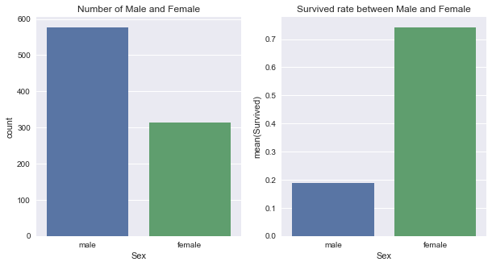

```python
fig, (axis1,axis2) = plt.subplots(1,2,figsize=(10,5))
axis1.set_title('Number of Male and Female')
axis2.set_title('Survived rate between Male and Female')

sns.countplot(x='Sex', data=Titanic, ax=axis1)

# average of survived for each Person(male, female)
person_perc = Titanic[["Sex", "Survived"]].groupby(['Sex'],as_index=False).mean()
sns.barplot(x='Sex', y='Survived', data=person_perc, ax=axis2, order=['male','female'])
```

From charts above, we cold see that female had much higher survived rate, which is more than 50%. Even through we could see that acutally more male on this ship than female.

### Pclass

```python
Titanic.groupby('Pclass').mean()
```

| Pclass | PassengerId | Survived | SibSp | Parch | Fare | Age |
| --- | --- | --- | --- | --- | --- | --- |
| 1 | 461.597222 | 0.629630 | 0.416667 | 0.356481 | 84.154687 | 37.122315 |
| 2 | 445.956522 | 0.472826 | 0.402174 | 0.380435 | 20.662183 | 29.792554 |
| 3 | 439.154786 | 0.242363 | 0.615071 | 0.393075 | 13.675550 | 26.254420 |

This table shows that Class 1 have a higher survived rate, which is more than 62% and Class 3 has lowest rate 24%

### Sibsp

```python
tempdf1 = Titanic[['SibSp', 'Survived']].groupby('SibSp').count().merge(Titanic[['SibSp', 'Survived']].groupby('SibSp').mean(), right_index = True, left_index = True)
tempdf1.columns = ['Count', 'Prob. Survived']
tempdf1
```

| SibSp | Count | Prob. Survived |
| --- | --- | --- |
| 0 | 608 | 0.345395 |
| 1 | 209 | 0.535885 |
| 2 | 28 | 0.464286 |
| 3 | 16 | 0.250000 |
| 4 | 18 | 0.166667 |
| 5 | 5 | 0.000000 |
| 8 | 7 | 0.000000 |

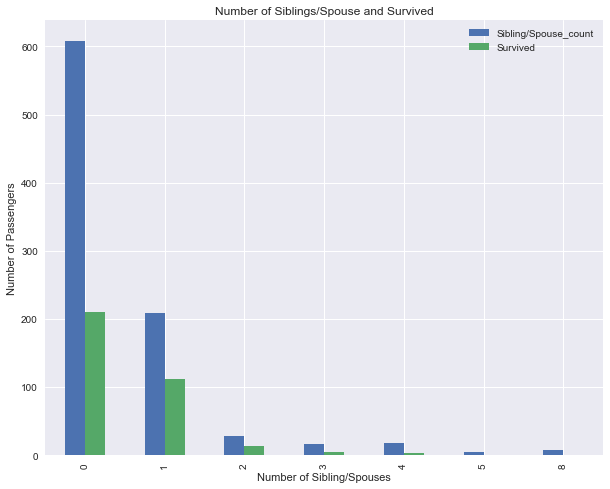

```python
tempdf12 = Titanic[['SibSp', 'Survived']].groupby('SibSp').count().merge(Titanic[['SibSp', 'Survived']].groupby('SibSp').sum(), right_index = True, left_index = True)
tempdf12.columns =['Sibling/Spouse_count','Survived']
tempdf12.plot.bar(figsize = (10, 8))
plt.title('Number of Siblings/Spouse and Survived')
plt.xlabel('Number of Sibling/Spouses')
plt.ylabel('Number of Passengers')
plt.show()
```

From two charts above, we could see the relationship between SibSp and survived. It looks like passengers with 1 or 2 sibsp has higher survivral rate. However, most people do not have sibling or spouse. And they only had survival rate 34%.

### Parch

```python
tempdf2 = Titanic[['Parch', 'Survived']].groupby('Parch').count().merge(Titanic[['Parch', 'Survived']].groupby('Parch').mean(), right_index = True, left_index = True)
tempdf2.columns = ['Count', 'Ratio. Survived']
tempdf2
```

| Parch | Count | Ratio. Survived |
| --- | --- | --- |
| 0 | 678 | 0.343658 |
| 1 | 118 | 0.550847 |
| 2 | 80 | 0.500000 |
| 3 | 5 | 0.600000 |
| 4 | 4 | 0.000000 |
| 5 | 5 | 0.200000 |
| 6 | 1 | 0.000000 |

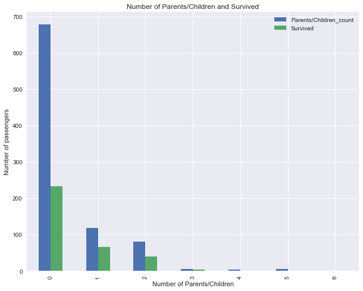

```python
tempdf22 = Titanic[['Parch', 'Survived']].groupby('Parch').count().merge(Titanic[['Parch', 'Survived']].groupby('Parch').sum(), right_index = True, left_index = True)
tempdf22.columns = ['Parents/Children_count','Survived']
tempdf22.plot.bar(figsize = (10, 8))
plt.title('Number of Parents/Children and Survived')
plt.xlabel('Number of Parents/Children')
plt.ylabel('Number of passengers')
plt.show()
```

From two charts above, we could see the similar relationship between Parch and survived. It looks like passengers with 1 to 3 Parents or children has higher survivral rate. However, most people do not have Parch. And they only had survival rate 34%.